# Experimental Designs and Linear Models

Alex Sanchez (asanchez@ub.edu)

June 2018

# Introduction and disclaimer

- The materials for this presentations have been borrowed from the videos of the excellent course -now extinct- PH525x Genomics Data Analysis.
- The course has evolved into three MOOCS which are simply **a must** for anyone interested in a serious application of statistics to omics sciences.

[HarvardX Biomedical Data Science Open Online Training](http://rafalab.github.io/pages/harvardx.html)

# From experimental designs to linear models

- An appropriate experimental design
  - Can save time and money in any type of experimental study,and as such in omics experiments.
  - Is the basis for estimating variability and estimating and comparing treatment effects.
  - Can be used to *deal* with problems such as confounding and batch effect.
- Experimental designs and linear models
  - Linear models assume a linear relation between a (*response*) variable, also called dependent variable and one or more (explanatory) variables(s) also called dependent variables.
  - Linear models provide a convenient setting to describe experimental designs and to analize data that has been obtained from experiments performed according to the design they describe (more about this later)

# Linear model of 2 groups = t-test

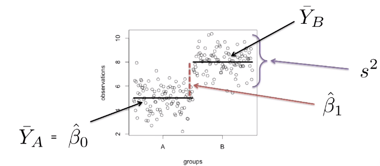

A comparison of two groups

# Two group comparison as linear model

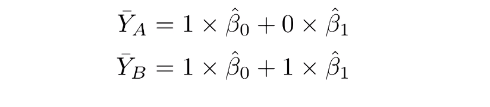

# Linear models in general

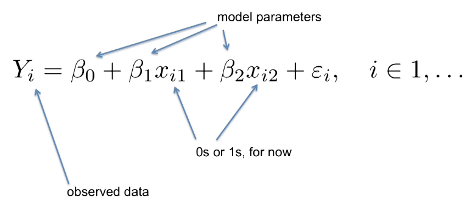

# Linear models of 3 groups

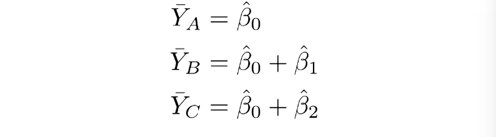

# Linear models of 3 groups $\neq$ t-tests

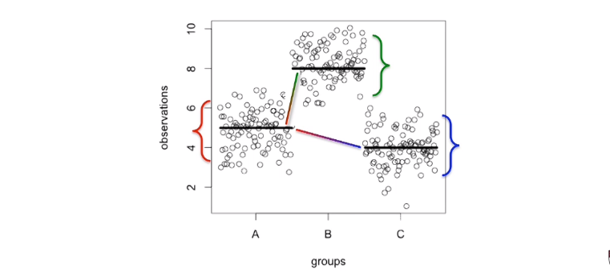

# Matrix notation for linear models

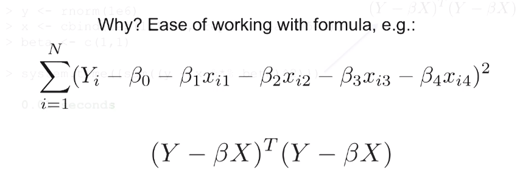

# Computers prefer matrices

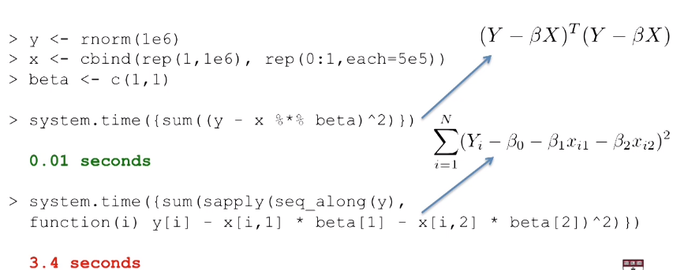

# Rewriting two groups in matrix notation

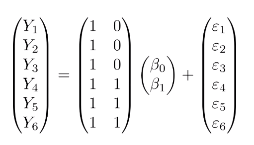

# Rewriting three groups in matrix notation

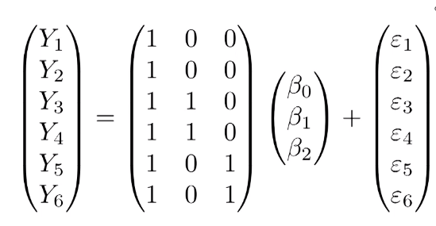

# Fitting linear models and Testing

Solving linear models

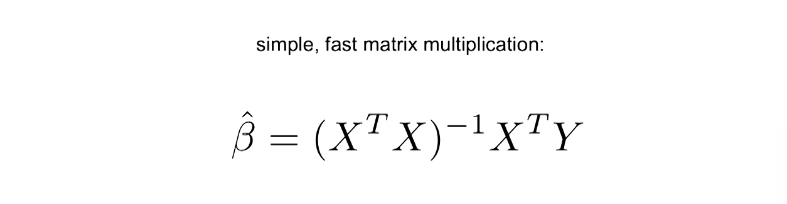

Testing significance

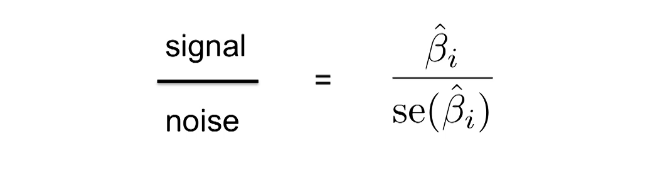

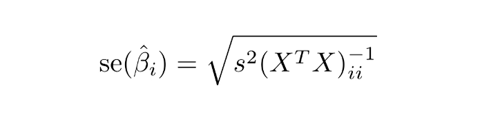

# The power of linear models: crossed designs

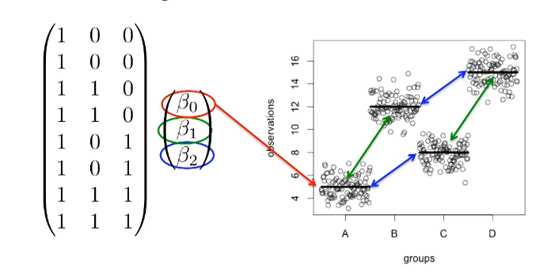

We assume effects are additive!

# Crossed designs with interaction

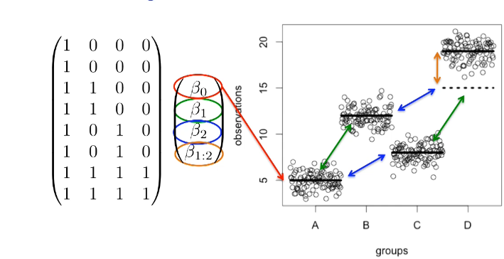

Interaction shows additional to additive effects

# How linear models are often used

A common quote in science papers:

*“The study of … controlled for age, race, and sex …”*

When what they really mean is:

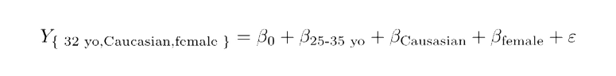

But **do we really believe that age effect is linear?**

# Linear models and the Design Matrix using R formulae

Here we will show how to use the two R functions, `formula` and `model.matrix`, in order to produce *design matrices* (also known as *model matrices*) for a variety of linear models.

For example a linear model to describe a study comparing diets in mice can be written as

$$Y_i = \beta_0 + \beta_1 x_i + \varepsilon_i, i=1,\dots,N$$

with $Y_i$ the weights and $x_i$ equal to 1 only when mouse $i$ receives the high fat diet.

We use the term *experimental unit* to $N$ different entities from which we obtain a measurement. In this case, the mice are the experimental units.

We call thees variables *indicator variables* since they simply indicate if the experimental unit had a certain characteristic or not.

We can use linear algebra to represent this model:

$$\mathbf{Y} = \begin{pmatrix}
Y_1\\
Y_2\\
\vdots\\
Y_N
\end{pmatrix}
,
\mathbf{X} = \begin{pmatrix}
1&x_1\\
1&x_2\\
\vdots\\
1&x_N
\end{pmatrix}
,
\boldsymbol{\beta} = \begin{pmatrix}
\beta_0\\
\beta_1
\end{pmatrix} \mbox{ and }
\boldsymbol{\varepsilon} = \begin{pmatrix}
\varepsilon_1\\
\varepsilon_2\\
\vdots\\
\varepsilon_N
\end{pmatrix}$$

as:

$$\,
\begin{pmatrix}
Y_1\\
Y_2\\
\vdots\\
Y_N
\end{pmatrix} =
\begin{pmatrix}
1&x_1\\
1&x_2\\
\vdots\\
1&x_N
\end{pmatrix}
\begin{pmatrix}
\beta_0\\
\beta_1
\end{pmatrix} +
\begin{pmatrix}
\varepsilon_1\\
\varepsilon_2\\
\vdots\\
\varepsilon_N
\end{pmatrix}$$

or simply:

$$\mathbf{Y}=\mathbf{X}\boldsymbol{\beta}+\boldsymbol{\varepsilon}$$

The design matrix is the matrix $\mathbf{X}$.

Once we define a design matrix, we are ready to find the least squares estimates. We refer to this as *fitting the model*.

We have seen that this can be expressed in matrix notation as:

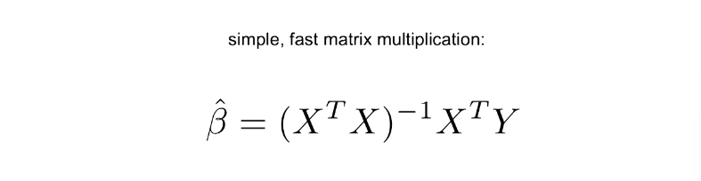

In practice however **we rarely compute directly the expression above**.

Instead, for fitting linear models in R, we will provide a *formula* to the `lm` function.

This is illustrated in the following slides using the `model.matrix` function, which is used internally by the `lm` function.

This will help us to connect the R `formula` with the matrix $\mathbf{X}$. It will therefore help us interpret the results from `lm`.

# Expressing experimental designs using R formula

We will show how to use the two base R functions

- `formula`
- `model.matrix`

in order to produce *design matrices* (also known as *model matrices*) for a variety of linear models.

The choice of design matrix is a critical step in linear modeling as it encodes which coefficients will be fit in the model, and the inter-relationship between the samples.

Suppose we have two groups, 1 and 2, with two samples each. We might start to encode this experimental design like so:

```r
x <- c(1,1,2,2)
f <- formula(~ x)
f
```

```
## ~x
```

Note that an intercept will be included by default, so the formula could equivalently be written: `~ x + 1`.

We can then inspect the design matrix which is formed by this:

```r
model.matrix(f)
```

```
##   (Intercept) x
## 1           1 1
## 2           1 1
## 3           1 2
## 4           1 2
## attr(,"assign")
## [1] 0 1
```

Note, this is not the design matrix we wanted.

We should instead first tell R that these values should not be interpreted numerically, but as different levels of a factor variable:

```r
x <- factor(c(1,1,2,2))
model.matrix(~ x)
```

```
##   (Intercept) x2
## 1           1  0
## 2           1  0
## 3           1  1
## 4           1  1
## attr(,"assign")
## [1] 0 1
## attr(,"contrasts")
## attr(,"contrasts")$x
## [1] "contr.treatment"
```

Now we have achieved the correct design matrix.

# More groups

Here we show the design matrix for an experiment with three groups:

```r
x <- factor(c(1,1,2,2,3,3))
model.matrix(~ x)
```

```
##   (Intercept) x2 x3
## 1           1  0  0
## 2           1  0  0
## 3           1  1  0
## 4           1  1  0
## 5           1  0  1
## 6           1  0  1
## attr(,"assign")
## [1] 0 1 1
## attr(,"contrasts")
## attr(,"contrasts")$x
## [1] "contr.treatment"
```

Now we have a third column which specifies which samples belong to the third group.

An alternate formulation of design matrix is possible by specifying `+ 0` in the formula:

```r
x <- factor(c(1,1,2,2,3,3))
model.matrix(~ x + 0)
```

```
##   x1 x2 x3
## 1  1  0  0
## 2  1  0  0
## 3  0  1  0
## 4  0  1  0
## 5  0  0  1
## 6  0  0  1
## attr(,"assign")
## [1] 1 1 1
## attr(,"contrasts")
## attr(,"contrasts")$x
## [1] "contr.treatment"
```

This group now fits a separate coefficient for each group.

In order to compare the levels to each other, we need to use some additional steps, which is called **the construction of contrasts**. These are covered in a presentation provided after this one or in the `limma` package vignette for microarray analysis with multiple groups.

# More variables

We can simply add additional variables with a `+` sign, in order to build a design matrix which fits based on the information in additional variables:

```r
x <- factor(c(1,1,1,1,2,2,2,2))
y <- factor(c("a","a","b","b","a","a","b","b"))
model.matrix(~ x + y)
```

```
##   (Intercept) x2 yb
## 1           1  0  0
## 2           1  0  0
## 3           1  0  1
## 4           1  0  1
## 5           1  1  0
## 6           1  1  0
## 7           1  1  1
## 8           1  1  1
## attr(,"assign")
## [1] 0 1 2
## attr(,"contrasts")
## attr(,"contrasts")$x
## [1] "contr.treatment"
##
## attr(,"contrasts")$y
## [1] "contr.treatment"
```

We could say that this linear model accounts for differences in both the x and y variables.

We assume in the above model specification, that the effect of the x and y variables are simply additive. Being in group 2 and group b is equal to the difference between 2 and 1 and the difference between b and a.

Another model is possible which fits and additional term, which encodes the potential interaction of x and y variables. This can be written in either of the following two formula:

```r
model.matrix(~ x + y + x:y)
```

```
##   (Intercept) x2 yb x2:yb
## 1           1  0  0     0
## 2           1  0  0     0
## 3           1  0  1     0
## 4           1  0  1     0
## 5           1  1  0     0
## 6           1  1  0     0
## 7           1  1  1     1
## 8           1  1  1     1
## attr(,"assign")
## [1] 0 1 2 3
## attr(,"contrasts")
## attr(,"contrasts")$x
## [1] "contr.treatment"
##
## attr(,"contrasts")$y
## [1] "contr.treatment"
```

```r
model.matrix(~ x*y)
```

```
##   (Intercept) x2 yb x2:yb
## 1           1  0  0     0
## 2           1  0  0     0
## 3           1  0  1     0
## 4           1  0  1     0
## 5           1  1  0     0
## 6           1  1  0     0
## 7           1  1  1     1
## 8           1  1  1     1
## attr(,"assign")
## [1] 0 1 2 3
## attr(,"contrasts")
## attr(,"contrasts")$x
## [1] "contr.treatment"
##
## attr(,"contrasts")$y
## [1] "contr.treatment"
```

# Linear models for microarray data

To see an extended presentation of linear models and its application to (continuos) omics data matrices you can give a look to the following presentation:

Linear Models for microarrays